# Covid-19 Mortality Analysis

Felix Reynoso

5/29/2021

# Introduction

The COVID-19 pandemic, is an ongoing global pandemic of coronavirus disease. The virus was first identified in December 2019 in Wuhan, China. The World Health Organization declared a International Health Emergency on 30 January 2020, and was later declared a pandemic on 11 March 2020.

In our analysis we explore mortality rates of the COVID-19 virus. We use the [COVID-19 Data Repository by the Center for Systems Science and Engineering (CSSE) at Johns Hopkins University](https://github.com/CSSEGISandData/COVID-19). With this short description we proceed with our analysis.

# Rate of Spread of COVID-19

The first case of COVID-19 was officially identified on December 2019 in Wuhan, China, and our data goes back to as early as January 2020.

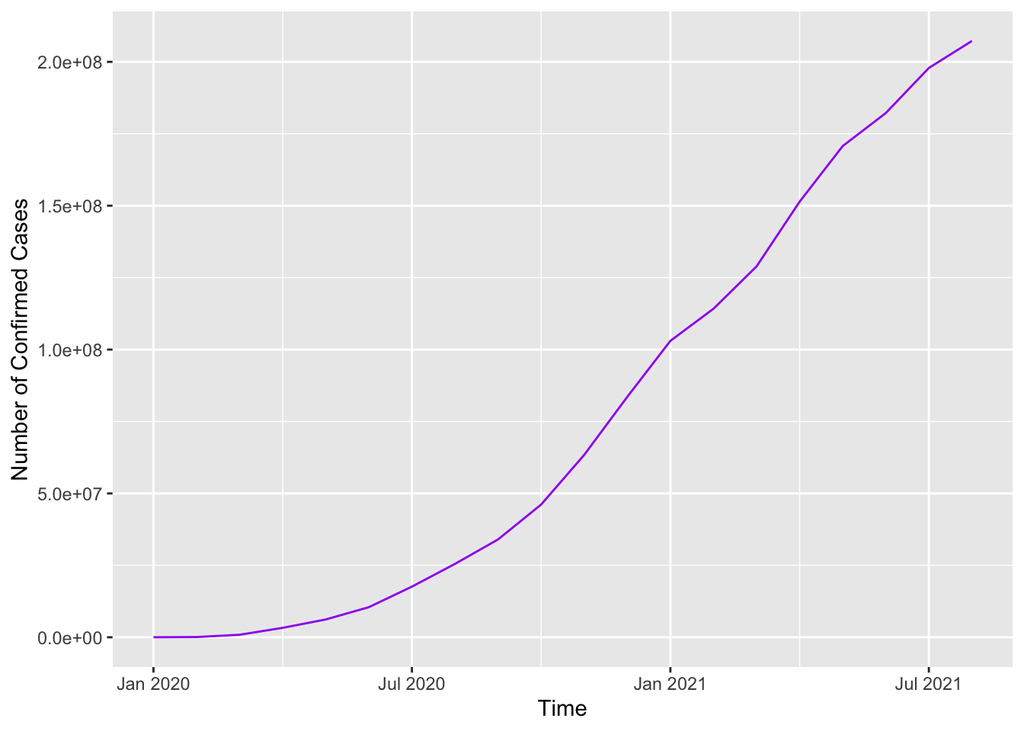

```r
# Adds up the total number of Covid cases each country has had, overtime.
df <- global_cases %>% select(-'Province/State', -'Lat', -'Long', -'Country/Region' )
df <- data.frame(date = names(df), total_cases = colSums(df)) %>%
  mutate(date = mdy(date)) %>%
  mutate(year = year(date), month = month(date)) %>%
  group_by(year, month) %>%
  summarize(cases=max(total_cases)) %>%
  mutate(date=as.yearmon(paste(year, month, sep='-'))) %>%
  ungroup() %>%
  select(date, cases)

ggplot(df, aes(x = date, y = cases)) +
  geom_line(color="purple") +
  labs(x = "Time", y = "Number of Confirmed Cases")
```

## COVID-19 Mortality Rate

Now we would like to explore the mortality rate of the virus, this rate is the percentage of deaths by cases, which is given by the number deaths divided by the number of confirmed cases.

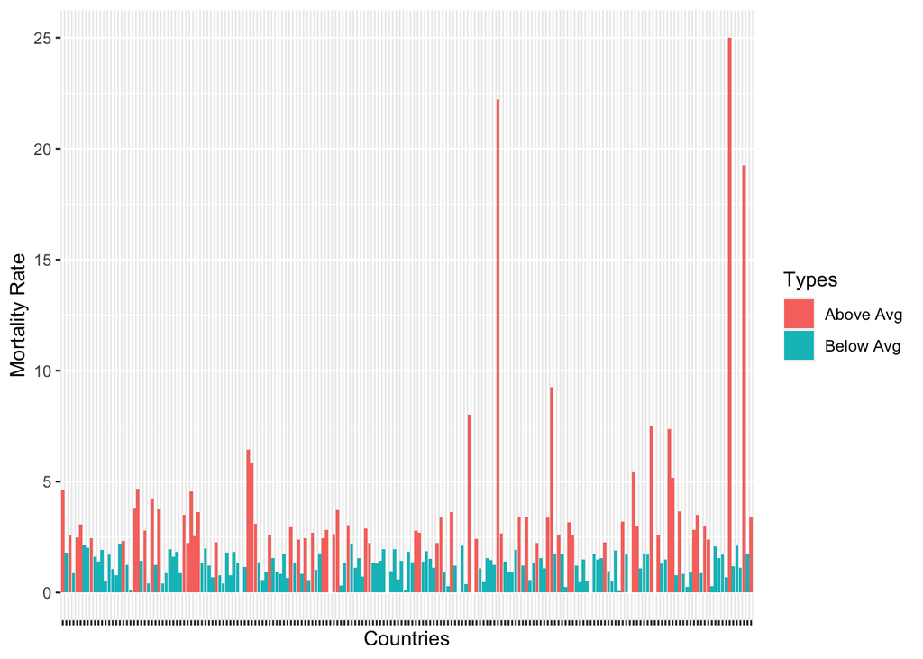

```r
# Plots the Mortality Rates of all countries
latest <- colnames(global_cases) %>% last()

cases <- global_cases %>%
  select('Country/Region', all_of(latest)) %>%
  rename(Total_Cases = all_of(latest), Country='Country/Region')

cases <- aggregate(Total_Cases ~ Country, cases, sum)

deaths <- global_deaths %>%
  select('Country/Region', all_of(latest)) %>%
  rename(Total_Deaths = all_of(latest), Country = 'Country/Region')

deaths <- aggregate(Total_Deaths ~ Country, deaths, sum)

df <- inner_join(cases, deaths, by = 'Country') %>%
  mutate(Death_Rate=(Total_Deaths/Total_Cases)*100)

df <- na.omit(df)

global_death_rate <- mean(df$Death_Rate) # Compute the avg global mortality rate

ggplot(df, aes(x = Country, y = Death_Rate)) +
  geom_col(aes(fill=ifelse(Death_Rate >= global_death_rate,"Above Avg","Below Avg"))) +
  theme(axis.text.x=element_blank()) +
  labs(x="Countries", y = "Mortality Rate", fill="Types")
```

The global average mortality rate of the COVID-19 is 2.2186284%, but from the above graph we can see that many countries, are way above this average.

Here are the ten countries with the highest mortality rate.

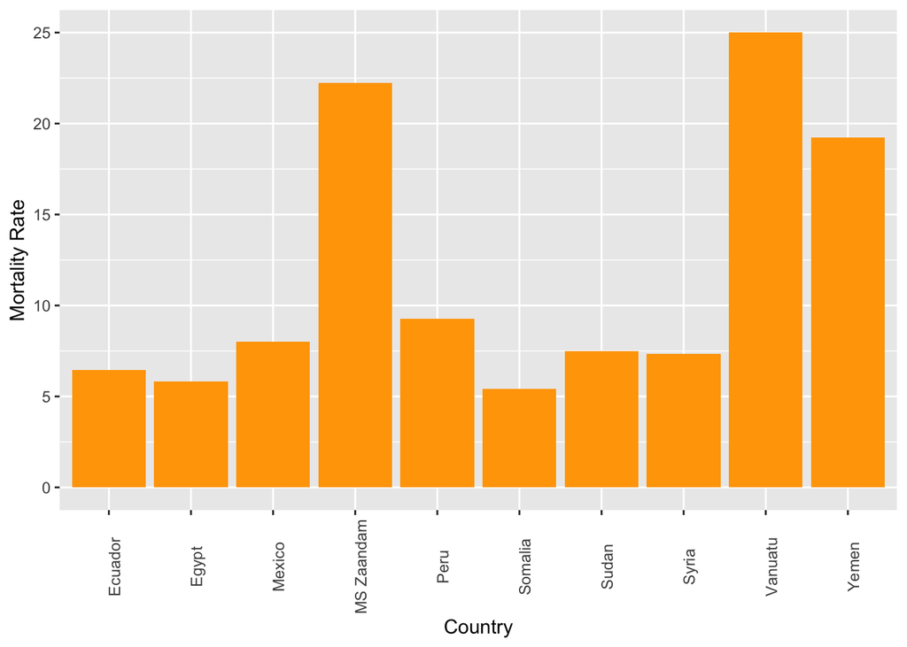

```r
# Plots the 10 counties with highest mortality mate
df1 <- df %>%
  arrange(Death_Rate) %>%
  tail(n=10)

ggplot(df1, aes(x = Country, y = Death_Rate)) +
  geom_col(fill = "orange") +
  theme(axis.text.x = element_text(angle = 90)) +
  ylab("Mortality Rate")
```

## Relationship Between Countries GDP and Mortality Rate

We have seen that mortality rates widely vary by country, this could be due to many factors, but we would like to establish a relationship between the mortality rate of the virus and countries GDP, to examine if there exists any correlation between these two variables.

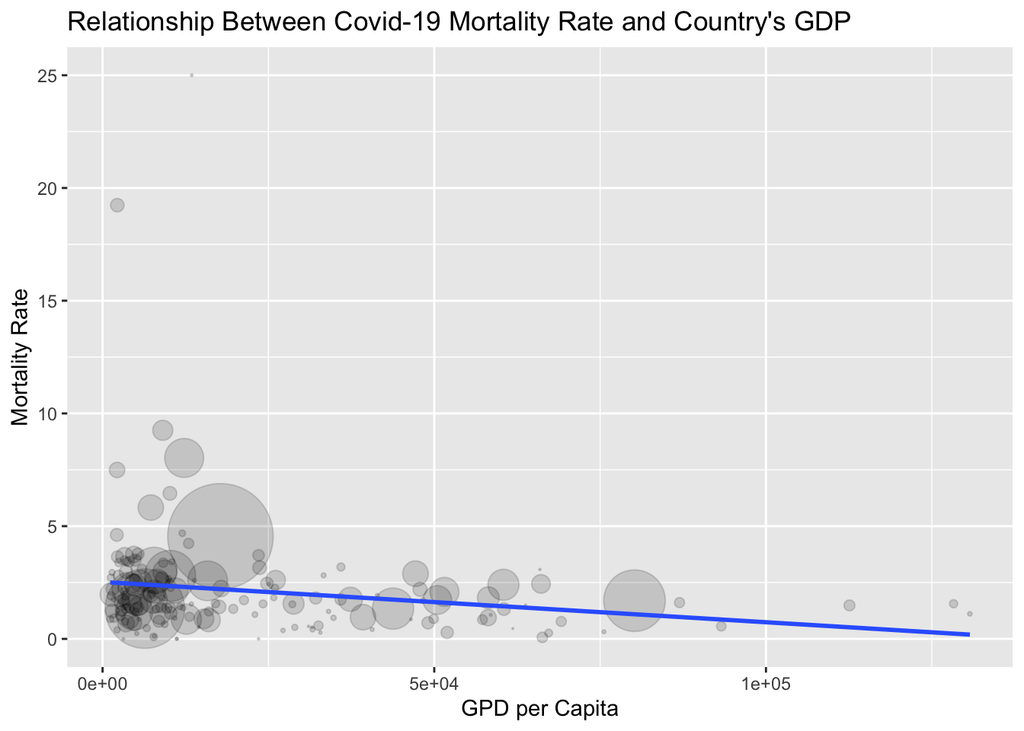

```r
# Plot a bubble chart, and regression line
ggplot(df, aes(x = GDP_Per_Capita, y = Death_Rate, size = Population)) +
  geom_point(alpha=.15, color="black") +
  scale_size(range = c(.1, 24), name="Population") +
  labs(
    title = "Relationship Between Covid-19 Mortality Rate and Country's GDP",
    x = 'GPD per Capita',
    y = "Mortality Rate") +
  geom_smooth(method = "lm", se = FALSE) +
  theme(legend.position = "none")
```

```r
cor <- df %>% get_correlation(formula = Death_Rate ~ GDP)
```

## Bias

Before performing this analysis I had previously watched [The best stats you’ve ever seen - Hans Rosling](https://www.youtube.com/watch?v=usdJgEwMinM), a Ted talk where the famous statistician Hans Rosling was doing an analysis of the correlation between countries GDPs and child survival rates. I took inspiration from that presentation and thought that if there was a correlation between child survival and GDP, there would probably be a correlation between COVID-19 mortality rates and countries GDP. And it seems a little obvious since generally the higher the GDP, the better the health systems a country has, and therefore the better they can ensure the safety of their citizens.

This was a possible source of bias I was able to identify during my analysis.

# Conclusion